# Analysis of brain reperfusion

Author

Affiliation

Daniel Manrique-Castano

Univerisity Laval (Laboratory of neurovascular interactions)

Published

Tuesday, March 19, 2024

Keywords

Stroke, Brain reperfusion, PDGF-D, Brain pericytes

# 1 Load libraries and themes

We load required libraries and visual themes

```r
library(jtools)
library(ggplot2)
library(interactions)
library(dplyr)
library(tidyr)
library(ggdist)
library(ggplot2)
library(broom)
library(distributional)
library(patchwork)

Plot_theme <- theme_classic() +
  theme(
      plot.title = element_text(size=18, hjust = 0.5, face="bold"),
      plot.subtitle = element_text(size = 10, color = "black"),
      plot.caption = element_text(size = 12, color = "black"),
      axis.line = element_line(colour = "black", linewidth = 1, linetype = "solid"),
      axis.ticks.length=unit(3,"pt"),

      axis.title.x = element_text(colour = "black", size = 16),
      axis.text.x = element_text(colour = "black", size = 16, angle = 0, hjust = 0.5),
      axis.ticks.x = element_line(colour = "black", linewidth = 1),

      axis.title.y = element_text(colour = "black", size = 18),
      axis.text.y = element_text(colour = "black", size = 16),
      axis.ticks.y = element_line(colour = "black", linewidth = 1),

      legend.position="right",
      legend.direction="vertical",
      legend.title = element_text(colour="black", face="bold", size=12),
      legend.text = element_text(colour="black", size=10),

      plot.margin = margin(t = 10,  # Top margin
                             r = 2,  # Right margin
                             b = 10,  # Bottom margin
                             l = 10) # Left margin
      )
```

# 2 Load the data

We load the `2024_Stroke_Pdgfd/Speckle.csv’ dataset containing the laser speckle measurements of brain reperfusion performed at baseline, 1 and 7 days after stroke. We then subset the dataset to perform linear regression for baseline (0) and 1 day after stroke, and another for baseline (0) and 7 days after stroke.

```r
# Load the dataset
Data <- read.csv("D:/Research/Support_EAE/2024_Stroke_Pdgfd/Data/Speckle.csv", header = TRUE)

# Setup factors
Data$Group <- factor(Data$Group, levels = c("VEH", "P250"))
Data$Time_fac <- factor(Data$Time_fac, levels = c("5min", "24h", "1W"))

# Subset the data
Data_subA <- Data[Data$Time != "1", ]
Data_subB <- Data[Data$Time != "7", ]

head(Data_subA)
```

```
  MouseId Group Time Time_fac   Ipsi Contra Contra_Ipsi
1      A1   VEH    0     5min 27.210 44.655      35.930
2      A2   VEH    0     5min 21.865 43.745      32.800
3      A3   VEH    0     5min 21.430 41.335      31.380
4      A4   VEH    0     5min 23.360 38.890      31.125
5      A5   VEH    0     5min 23.075 50.455      36.760
6      A6  P250    0     5min 23.080 40.750      31.910
```

# 3 Fitting the linear models

Next, we fit two separate linear models for the subsets using the standard `lm` function:

```r
# For 0-1 DAY
fit1 <- lm(Contra_Ipsi ~ Time*Group, data = Data_subB)

# For 0-7 DAY
fit2 <- lm(Contra_Ipsi ~ Time*Group, data = Data_subA)
```

# 4 Summary results

We visualize the results using the `summary` function

```r
summary(fit1)
```

```
Call:
lm(formula = Contra_Ipsi ~ Time * Group, data = Data_subB)

Residuals:
    Min      1Q  Median      3Q     Max
-6.9440 -2.2322 -0.7345  2.4847  8.4780

Coefficients:
               Estimate Std. Error t value Pr(>|t|)
(Intercept)      33.599      1.684  19.950 9.94e-13 ***
Time              4.723      2.382   1.983   0.0648 .
GroupP250         0.111      2.382   0.047   0.9634
Time:GroupP250    3.561      3.368   1.057   0.3061
---
Signif. codes:  0 '***' 0.001 '**' 0.01 '*' 0.05 '.' 0.1 ' ' 1

Residual standard error: 3.766 on 16 degrees of freedom
Multiple R-squared:  0.5194,    Adjusted R-squared:  0.4293
F-statistic: 5.764 on 3 and 16 DF,  p-value: 0.007187
```

```r
summary(fit2)
```

```
Call:
lm(formula = Contra_Ipsi ~ Time * Group, data = Data_subA)

Residuals:
   Min     1Q Median     3Q    Max
-6.732 -1.905 -0.325  2.409  4.112

Coefficients:
               Estimate Std. Error t value Pr(>|t|)
(Intercept)     33.5990     1.3874  24.217 4.92e-14 ***
Time             1.1741     0.2803   4.189 0.000695 ***
GroupP250        0.1110     1.9621   0.057 0.955587
Time:GroupP250   0.7504     0.3964   1.893 0.076581 .
---
Signif. codes:  0 '***' 0.001 '**' 0.01 '*' 0.05 '.' 0.1 ' ' 1

Residual standard error: 3.102 on 16 degrees of freedom
Multiple R-squared:  0.8108,    Adjusted R-squared:  0.7754
F-statistic: 22.86 on 3 and 16 DF,  p-value: 4.992e-06
```

The tables show the estimated parameters for each model. The ‘intercept’ represents the value for the vehicle animals at baseline. Time’ represents the effect (slope) of time (1 or 7 days) for the vehicle animals. Group250 is the effect of the intervention at baseline, while Time:GroupP250 is the difference in slope between genotypes from baseline to 1 or 7 days.

# 5 Visualization of results

Here we use the `interact_plot` function from the `interactions` package to plot the estimated intercepts and slopes. The plots are then stored in the designed locations and are available in the repository.

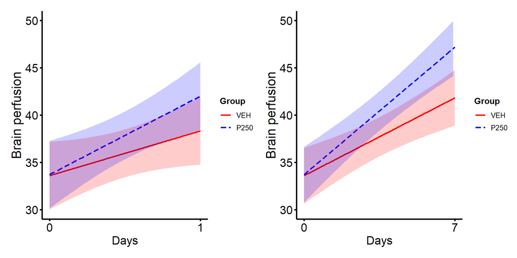

Figure 1

```r
fit1_fig <- interact_plot(fit1,
                          pred =
                          Time,
                          modx = Group,
                          interval = TRUE,
                          int.width = 0.95,
                          colors = c("red", "blue")) +

scale_y_continuous(name = "Brain perfusion",
                   limits = c(30,50)) +
scale_x_continuous(name = "Days",
                   breaks = c(0, 1)) +
Plot_theme

ggsave(
plot     = fit1_fig,
filename = "Plots/Fit1.png",
width    = 12,
height   = 9,
units    = "cm")

fit2_fig <- interact_plot(fit2,
                          pred = Time,
                          modx = Group,
                          interval = TRUE,
                          int.width = 0.95,
                          colors = c("red", "blue")) +

scale_y_continuous(name = "Brain perfusion",
                   limits = c(30,50)) +
scale_x_continuous(name = "Days",
                   breaks = c(0, 7)) +

Plot_theme

ggsave(
plot     = fit2_fig,
filename = "Plots/Fit2.png",
width    = 12,
height   = 9,
units    = "cm")

fit1_fig | fit2_fig
```

Figure 1 shows the results for the regression of baseline - 1 day (left) and baseline - 7 days (right).